# Advanced data analysis_HW 3

## 6.3 For which groups is the prediction model precise?

OLS correctly estimates the difference between genders for medium level of bulling (CI of OLS are crossing CI for quantile regression), overestimates the difference between genders for with very low and underestimates very high (90%) levels of bullying. (Coefficient is negative, therefore interpretation of overestimation and underestimation is contradicts the picture).

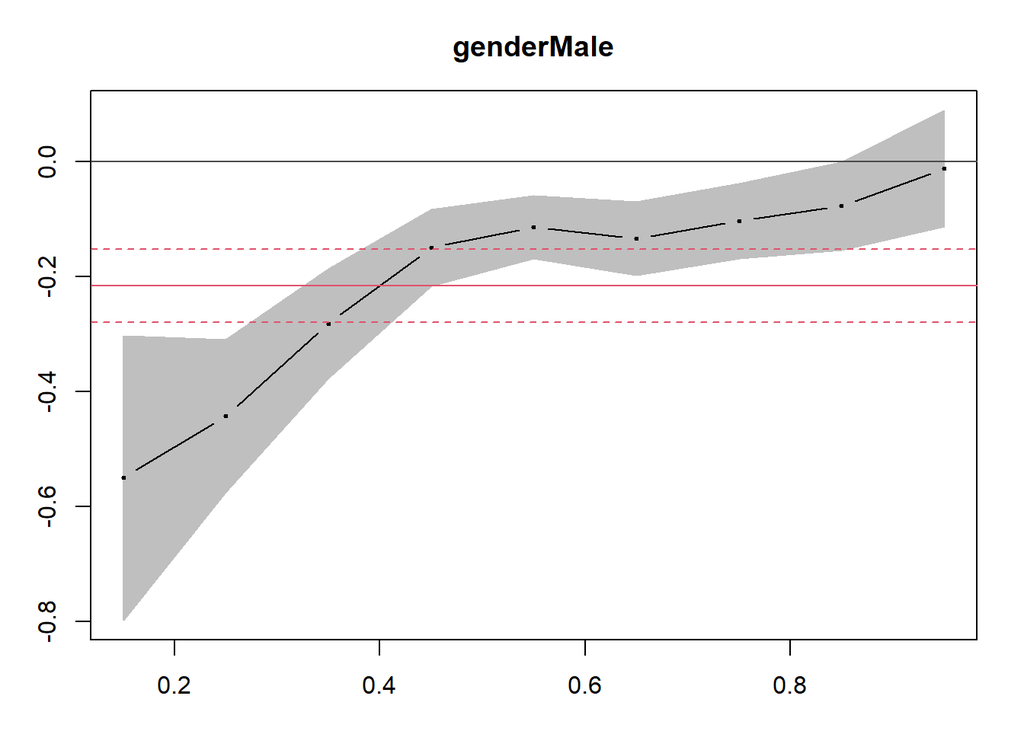

```r
library(quantreg)
q_plot <-  rq(bullying_rev ~ gender + belonging + dvd + math_step_100 + edu_mother,
                data = data_USA,
        tau = seq(.15, .95, by = 0.10))

summary(q_plot) %>%
  plot(c("genderMale"))
```

OLS correctly estimates the effect of belonging for the lowest level and high level of bulling (CI of OLS are crossing CI for quantile regression) and high, and underestimates middle (20-40%) levels of bullying. (Coefficient is negative, therefore interpretation of overestimation and underestimation is contradicts the picture).

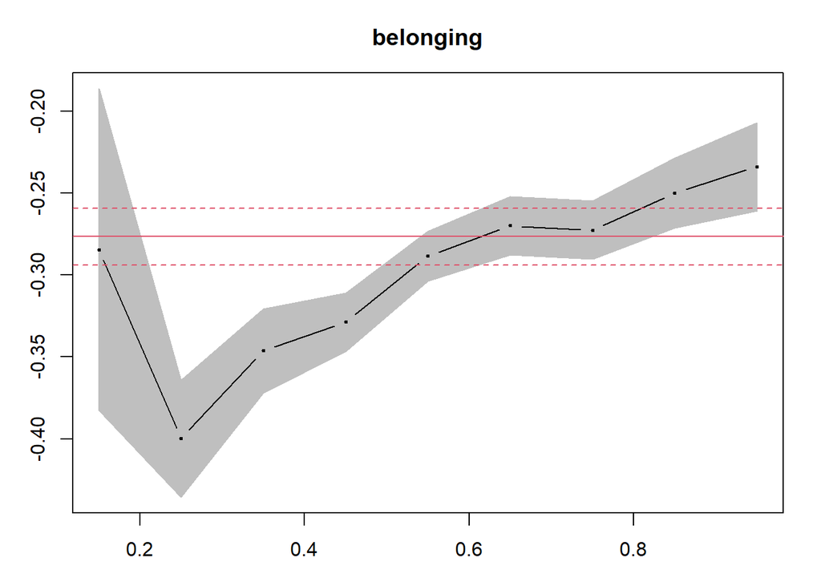

```r
summary(q_plot) %>%
  plot(c("belonging"))
```

OLS correctly estimates the effect owning DVD for all levels of bulling (CI of OLS are crossing CI for quantile regression).

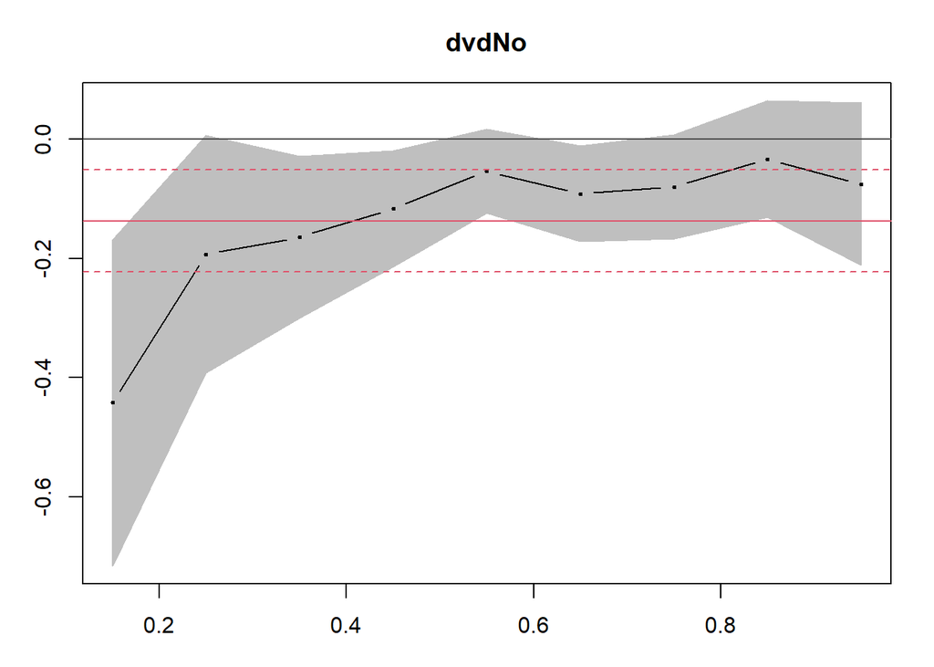

```r
summary(q_plot) %>%
  plot(c("dvdNo"))
```